# 7-enrichment-analysis.RMD

Ana BVA

16 October 2020

## Introduction

We previously had run the following scripts:

- 0: Data selection `/0-Data-selection.RMD`
- 1: Dowload RAW data `/1-download_raw-data.RMD`
- 2: Normalizing data `/2-normalizing-data.RMD`
- 3: Curating data `/3-curatig-data.RMD`
- 4: Differential gene expression analysis `/4-DE.RMD`
- 5: Merging data `/5-merge-data.RMD`
- 6: Merging data `/6-meta-analysis.RMD`

## Input

This script needs the following files:

**Data:** Meta-analysis results in `csv` files

## Analysis

### Setup

For running the script, type:

```bash
ssh -X aaltamirano@dna.lavis.unam.mx
qrsh
cd /mnt/Genoma/amedina/DataDNA/R-projects/Meta-analysis_COPD/output_data/.out
 module load r/4.0.1

## OR
ssh ana@10.200.0.42
cd /home/ana/DataDNA/R-projects/Meta-analysis_COPD/output_data/.out

nohup R -e "rmarkdown::render(here::here('vignettes/8-enrichment-pathways.RMD'))" > 8-enrichment-pathways.RMD.out &
```

The script can be found in: /Users/user/Documents/Doctorado/Analysis/Meta-analysis_COPD/vignettes. And the directories were set using `R/setup.R` (e.i. DATA, OUPUT, DOWNLOAD) as a small functions that will paste the names into complete paths.

```r
knitr::opts_knit$set(root.dir = here::here())
source(here::here("R/setup.R"))
```

And this analysis is run in: /Users/user/Documents/Doctorado/Analysis/Meta-analysis_COPD

### Libraries

```r
library(hypeR)
library(WGCNA)
library(tidyverse)
library(reactable)
```

### Import data

We will import DE results from all experiments.

```r
meta <- read_csv(OUTPUT("2020-10-16_Step6_meta-analysis.csv"))[,-1]
meta
```

```
## # A tibble: 24,129 x 10
##    genes          QEp estimate   pval    se    H2  tau2    I2 num_exp  qval
##    <chr>        <dbl>    <dbl>  <dbl> <dbl> <dbl> <dbl> <dbl>   <dbl> <dbl>
##  1 IL1R2    2.45e-131  -0.0729 0.877  0.469  53.0 2.31   98.1      11 0.968
##  2 SLCO4A1  9.98e- 95   0.107  0.791  0.406  27.3 1.46   96.3      10 0.941
##  3 FKBP5    1.88e-109   0.0127 0.969  0.330  36.4 1.10   97.3      11 0.994
##  4 SH3PXD2B 1.05e- 78   0.0529 0.812  0.222  26.5 0.415  96.2       9 0.949
##  5 GALNTL2  1.66e- 41  -0.122  0.770  0.418  29.7 0.819  96.6       5 0.936
##  6 IRAK3    3.64e- 58  -0.0301 0.890  0.217  25.8 0.393  96.1       9 0.972
##  7 TIMP4    2.42e- 64   0.0744 0.749  0.233  25.3 0.555  96.1      11 0.931
##  8 CEACAM4  9.96e- 56  -0.0384 0.851  0.205  36.3 0.373  97.2      10 0.960
##  9 SULT1B1  2.41e- 56  -0.0524 0.834  0.250  50.2 0.585  98.0      10 0.955
## 10 ITGA10   2.00e- 34  -0.356  0.0517 0.183  14.4 0.257  93.1       9 0.413
## # … with 24,119 more rows
```

### Ranking and weighted values

```r
qval_cutoff <- 0.5

df <- meta %>%
  filter(qval <= qval_cutoff) %>%
  dplyr::arrange(desc(estimate))

signature <- as.vector(df$qval)
names(signature) <- df$genes
head(signature)
```

```
##          FGG     MGC29506          IL8        CHIT1         FOSB     SERPIND1
## 1.957830e-01 6.648919e-08 1.570814e-01 1.386125e-01 3.193804e-01 6.961857e-03
```

### Enrichment analysis

We will use a function to generate plots from different databases

```r
enrich <- function(DB){
  # Ranked Signature using the estimator from the meta analysis (FC)
  hyp_obj <- hypeR(names(signature),DB, test="hypergeometric", background=nrow(meta), fdr=0.5, plotting=TRUE)
  hyp_obj$plots[[1]]
  hyp_obj

  # Weighted Signature using as ranking the estimator and the weighted the qvalue
  hyp_obj <- hypeR(signature, DB, test="kstest", background=nrow(meta),fdr=0.5, plotting=TRUE)
  hyp_obj$plots[[1]]
  hyp_obj

  # Show interactive table
  #hyp_show(hyp_obj)

  # Plot dots plot
  hyp_dots(hyp_obj) + theme_minimal()

  # Plot enrichment map
  #hyp_emap(hyp_obj)

  # Plot hiearchy map
  #hyp_hmap(hyp_obj)

  # Generate markdown report
  #hyp_to_rmd(hyp_obj,"hypr-KEGG-genesets.rmd")
  #hyp_to_rmd(hyp_obj,"hypr-TRANSFAC_and_JASPAR_PWMs.rmd")
}
```

```r
# KEGG
KEGG <- hyperdb_rgsets("KEGG", "92.0")
enrich(KEGG)

#HALLMARL
HALLMARK <- msigdb_gsets(species="Homo sapiens", category="H",clean = T)
enrich(HALLMARK)

#ENRICHR
TF_TJ <- enrichr_gsets("TRANSFAC_and_JASPAR_PWMs")
enrich(TF_TJ)

enrichR<- enrichr_gsets("Jensen_DISEASES")
enrich(enrichR)

enrichR<- enrichr_gsets("Jensen_TISSUES")
enrich(enrichR)

enrichR<- enrichr_gsets("Chromosome_Location")
enrich(enrichR)

enrichR<- enrichr_gsets("WikiPathways_2019_Human")
enrich(enrichR)


enrichR<- enrichr_gsets("ClinVar_2019")
enrich(enrichR)
```

```r
HALLMARK <- msigdb_gsets(species="Homo sapiens", category="H",clean = T)
```

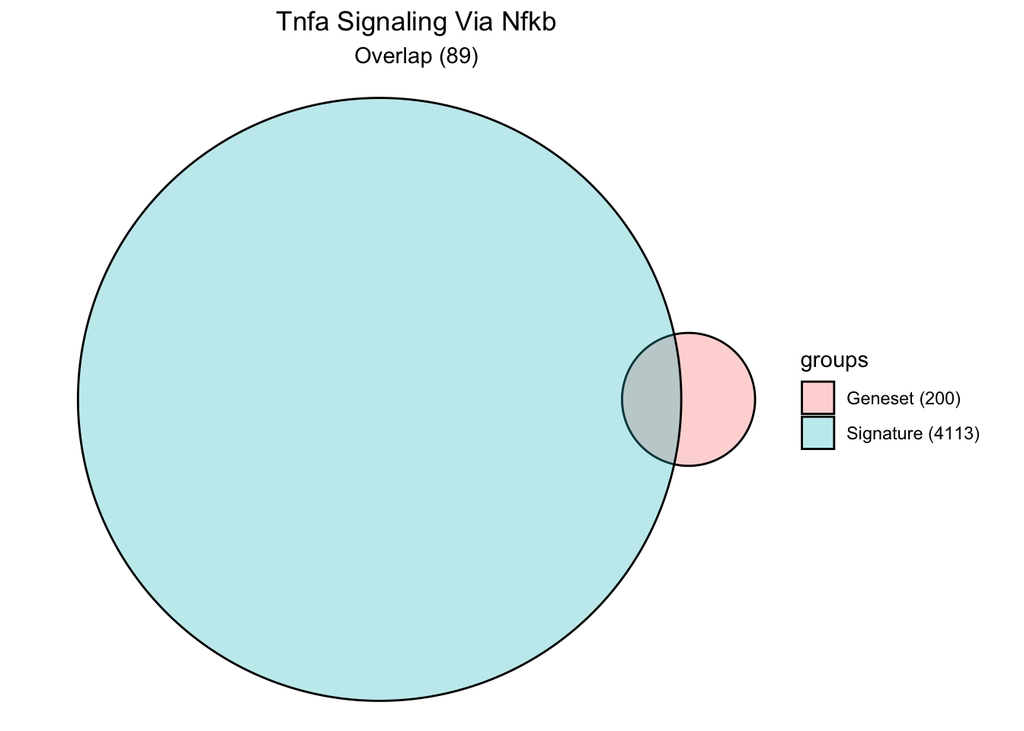

```r
DB <- HALLMARK
  # Ranked Signature using the estimator from the meta analysis (FC)
  hyp_obj <- hypeR(names(signature),DB, test="hypergeometric", background=nrow(meta), fdr=0.5, plotting=TRUE)
  hyp_obj$plots[[1]]
```

```r
  hyp_obj
```

```
## (hyp)
##
##   data:
##                              label    pval     fdr signature geneset overlap
##            Tnfa Signaling Via Nfkb 9.4e-20 4.7e-18      4113     200      89
##              Inflammatory Response 1.6e-07 3.9e-06      4113     200      64
##  Epithelial Mesenchymal Transition 3.7e-05 6.1e-04      4113     200      57
##                  Kras Signaling Up 7.3e-05 9.1e-04      4113     200      56
##                Il2 Stat5 Signaling 1.2e-04 1.2e-03      4113     199      55
##            Estrogen Response Early 1.4e-04 1.2e-03      4113     200      55
##  background
##       24129
##       24129
##       24129
##       24129
##       24129
##       24129
##                                                                                                                                                                                                                                                                                                          …
##  ATF3,ATP2B1,BCL2A1,BHLHE40,BIRC3,BMP2,BTG1,BTG2,CCL2,CCL20,CCNL1,CD44,CD69,CD83,CDKN1A,CLCF1,CSF1,CSF2,CXCL1,CXCL2,CXCL3,CXCL6,DUSP1,DUSP2,DUSP4,DUSP5,EDN1,EFNA1,EGR1,EGR2,EGR3,F2RL1,FOSB,FOSL1,GADD45A,GADD45B,GFPT2,GPR183,HBEGF,ICAM1,IER2,IER3,IL1A,IL1B,IL6,JUN,JUNB,KDM6B,KLF10,LIF,LITAF,MAFF,M…
##                                                                                                                                                                  ADORA2B,AHR,ATP2B1,BDKRB1,BTG2,CCL2,CCL20,CCL22,CCL7,CCR7,CD48,CD69,CD70,CD82,CDKN1A,CLEC5A,CSF1,CSF3,CXCL6,CXCL8,CYBB,DCBLD2,EDN1,GPC3,…
##                                                                                                                                                                                               ADAM12,CD44,COL12A1,COL1A1,COL4A1,COL4A2,COL5A3,COMP,CTHRC1,CXCL1,CXCL12,CXCL6,CXCL8,FAP,FBLN2,FGF2,FLNA,FM…
##                                                                                                                                                                                       ALDH1A2,ALDH1A3,ANKH,BIRC3,BMP2,CAB39L,CCL20,CFB,CSF2,CSF2RA,CTSS,DCBLD2,DOCK2,EMP1,F2RL1,FLT4,GADD45G,GALNT3,GFPT2…
##                                                                                                                                                                                                                 ADAM19,AGER,AHR,ALCAM,BHLHE40,BMP2,CCR4,CD44,CD48,CD79B,CD83,CDC42SE2,CDCP1,CDKN1C,COCH,C…
##                                                                                                                                                                                      ABHD2,AKAP1,ALDH3B1,ANXA9,ASB13,BCL11B,BHLHE40,BLVRB,CA12,CALB2,CBFA2T3,CD44,CHPT1,CXCL12,DEPTOR,DHRS3,EGR3,ELOVL2,F…
##
##   plots: 26 Figures
##
##   args: signature
##         genesets
##         test
##         background
##         power
##         absolute
##         pval
##         fdr
##         plotting
##         quiet
```

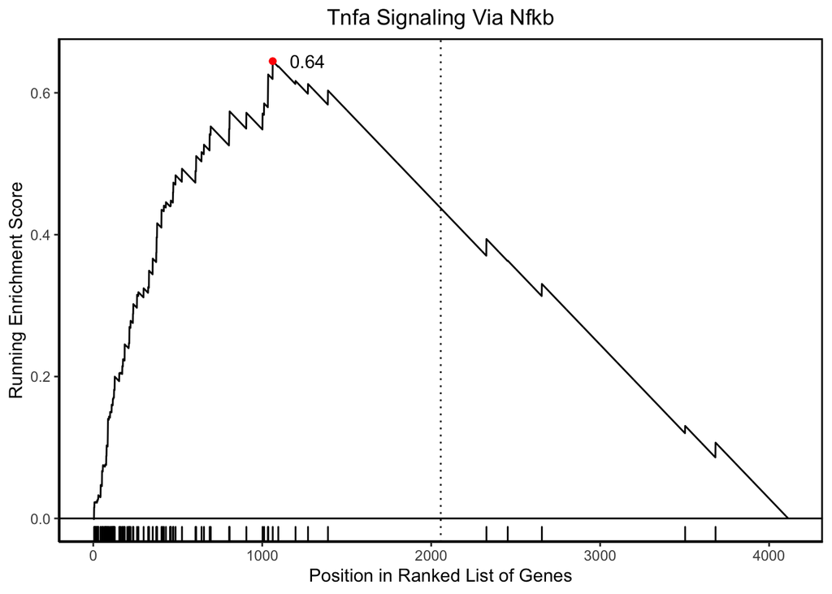

```r
  # Weighted Signature using as ranking the estimator and the weighted the qvalue
  hyp_obj <- hypeR(signature, DB, test="kstest", background=nrow(meta),fdr=0.5, plotting=TRUE)
  hyp_obj$plots[[1]]
```

```r
  hyp_obj
```

```
## (hyp)
##
##   data:
##                              label    pval     fdr signature geneset overlap
##            Tnfa Signaling Via Nfkb 4.3e-32 2.1e-30      4113     200      89
##              Inflammatory Response 3.3e-19 8.2e-18      4113     200      64
##                Il2 Stat5 Signaling 3.1e-10 5.2e-09      4113     199      55
##                Allograft Rejection 3.4e-09 4.2e-08      4113     200      53
##                  Kras Signaling Up 5.5e-09 5.5e-08      4113     200      56
##  Epithelial Mesenchymal Transition 4.6e-08 3.8e-07      4113     200      57
##  score
##   0.64
##   0.58
##   0.45
##   0.43
##   0.41
##   0.39
##
##   plots: 35 Figures
##
##   args: signature
##         genesets
##         test
##         background
##         power
##         absolute
##         pval
##         fdr
##         plotting
##         quiet
```

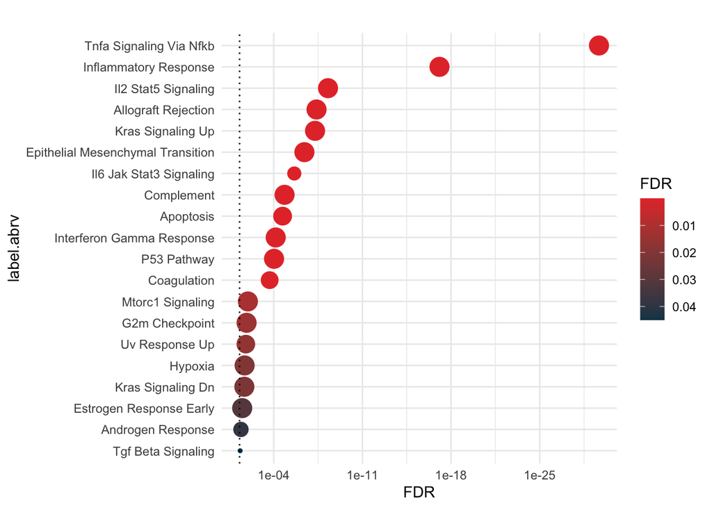

```r
  # Show interactive table
  #hyp_show(hyp_obj)

  # Plot dots plot
  hyp_dots(hyp_obj) + theme_minimal()
```

```r
  # Plot enrichment map
  #hyp_emap(hyp_obj)

  # Plot hiearchy map
  #hyp_hmap(hyp_obj)

  # Generate markdown report
  #hyp_to_rmd(hyp_obj,"hypr-KEGG-genesets.rmd")
  #hyp_to_rmd(hyp_obj,"hypr-TRANSFAC_and_JASPAR_PWMs.rmd")
```

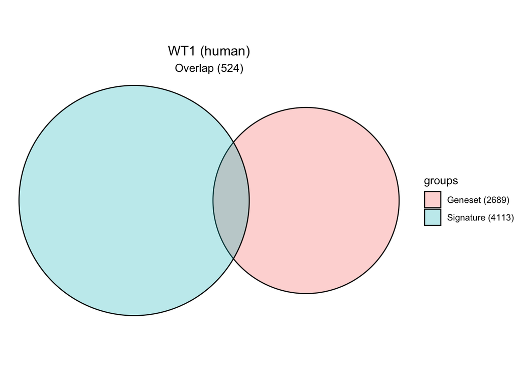

```r
TF_TJ <- enrichr_gsets("TRANSFAC_and_JASPAR_PWMs")
DB <- TF_TJ
  # Ranked Signature using the estimator from the meta analysis (FC)
  hyp_obj <- hypeR(names(signature),DB, test="hypergeometric", background=nrow(meta), fdr=0.5, plotting=TRUE)
  hyp_obj$plots[[1]]
```

```r
  hyp_obj
```

```
## (hyp)
##
##   data:
##           label    pval   fdr signature geneset overlap background
##     WT1 (human) 0.00024 0.058      4113    2689     524      24129
##   NFKB1 (human) 0.00036 0.058      4113    3497     667      24129
##     SP3 (human) 0.00090 0.098      4113    1332     270      24129
##    E2F1 (human) 0.00200 0.150      4113    4207     782      24129
##  HIVEP1 (human) 0.00230 0.150      4113     218      54      24129
##    NFE2 (human) 0.00320 0.150      4113    2681     508      24129
##                                                                                                                                                                                                                                                                                                          …
##                                                                                                                                                                                                                                                                                                          …
##                                                                                                                                                                                                                                                                                                          …
##                                                                                                                                                                                                                                                                                                          …
##  BAD,COMTD1,KIAA0247,MPPE1,PTPDC1,DPYSL5,ZNF16,ZNF26,FAM110A,ALKBH5,DUSP4,DUSP1,DUSP2,ZNF34,BMP8A,MMP16,KIR3DL2,FAM116B,FAM116A,APEX1,TP53I13,FADS3,NEFM,TP53I11,FBXO17,CTNNBIP1,PDCD1,AGRN,MAP3K8,KCND2,KCND3,NEK6,MINPP1,NOXA1,BCAT1,BLM,TRIM71,NFATC2IP,TRIM65,TNFRSF19,SON,KIAA1539,BCAR1,RDH10,BCAS3…
##                                                                                                                                                                                                                                                                                                          …
##                                                                                                                                                                                                                                                                                                          …
##
##   plots: 37 Figures
##
##   args: signature
##         genesets
##         test
##         background
##         power
##         absolute
##         pval
##         fdr
##         plotting
##         quiet
```

[figure not shown]

```r
  # Weighted Signature using as ranking the estimator and the weighted the qvalue
  hyp_obj <- hypeR(signature, DB, test="kstest", background=nrow(meta),fdr=0.5, plotting=TRUE)
  hyp_obj$plots[[1]]
```

```r
  hyp_obj
```

```
## (hyp)
##
##   data:
##           label    pval    fdr signature geneset overlap score
##     MYB (human) 2.5e-05 0.0042      4113    1409     237  0.15
##    JUND (human) 2.6e-05 0.0042      4113    1380     222  0.16
##     FOS (human) 6.7e-05 0.0065      4113    1394     246  0.14
##  POU1F1 (human) 8.0e-05 0.0065      4113    1408     231  0.15
##    SPI1 (mouse) 4.9e-04 0.0270      4113    1680     246  0.13
##  NFATC2 (human) 5.0e-04 0.0270      4113     117      26  0.38
##
##   plots: 29 Figures
##
##   args: signature
##         genesets
##         test
##         background
##         power
##         absolute
##         pval
##         fdr
##         plotting
##         quiet
```

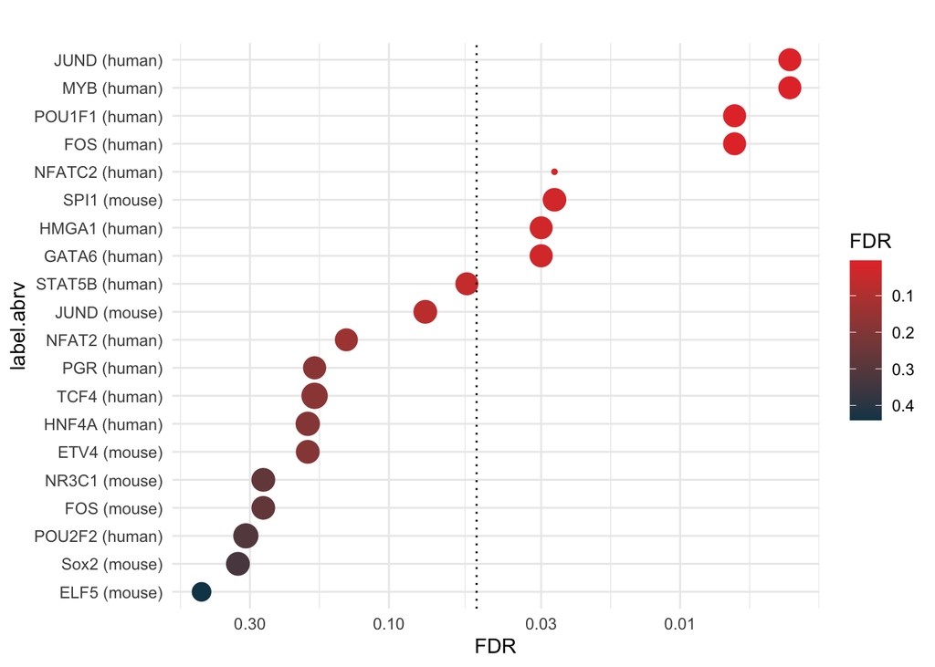

```r
  # Show interactive table
  #hyp_show(hyp_obj)

  # Plot dots plot
  hyp_dots(hyp_obj) + theme_minimal()
```

```r
  # Plot enrichment map
  #hyp_emap(hyp_obj)

  # Plot hiearchy map
  #hyp_hmap(hyp_obj)

  # Generate markdown report
  #hyp_to_rmd(hyp_obj,"hypr-KEGG-genesets.rmd")
  #hyp_to_rmd(hyp_obj,"hypr-TRANSFAC_and_JASPAR_PWMs.rmd")
```

## Output

This script produces the following data, and can be found in /Users/user/Documents/Doctorado/Analysis/Meta-analysis_COPD

**Figures in the vignette:** Enrichment analysis with plots